# K-12 shootings

Captain Peaches

December 11, 2018

## Setup & Data

Load data

# Take a peek

First exmaine the structure of the data, as well as the type and structure of the variables.

```r
str(dat)
```

```
## 'data.frame':    1328 obs. of  48 variables:
##  $ Date                                                                                                                                              : Factor w/ 1226 levels "1/1/1976","1/10/1995",..: 123 123 123 607 683 761 792 962 866 1070 ...
##  $ School                                                                                                                                            : Factor w/ 1155 levels "\nOttawa Hills High School",..: 455 958 1052 513 239 830 828 151 74 888 ...
##  $ City                                                                                                                                              : Factor w/ 669 levels "Aberdeen","Abilene",..: 636 636 636 130 339 489 658 170 447 196 ...
##  $ State                                                                                                                                             : Factor w/ 53 levels "AK","AL","AR",..: 8 8 8 36 5 3 9 10 47 46 ...
##  $ Reliability.Score..1.5.                                                                                                                           : int  3 3 2 2 2 3 3 2 2 2 ...
##  $ Killed..includes.shooter.                                                                                                                         : int  1 0 0 0 0 1 1 0 0 0 ...
##  $ Wounded                                                                                                                                           : int  0 1 0 1 2 5 0 1 2 1 ...
##  $ Total.Injured.Killed.Victims                                                                                                                      : int  1 1 0 1 2 6 1 1 2 1 ...
##  $ Gender.of.Victims..M.F.Both.                                                                                                                      : Factor w/ 5 levels "Both","Female",..: 3 3 4 3 3 1 3 3 1 3 ...
##  $ Victim.s.Affiliation.w..School                                                                                                                    : Factor w/ 16 levels "Bus Driver","Former School Employee",..: 13 13 8 13 6 13 13 13 6 13 ...
##  $ Victim.s.age.s.                                                                                                                                   : int  15 NA NA 18 NA NA 18 19 NA 15 ...
##  $ Victims.Race                                                                                                                                      : Factor w/ 8 levels "","Black","Multiple Races",..: 7 7 5 7 7 7 2 7 7 6 ...
##  $ Victim.Ethnicity                                                                                                                                  : Factor w/ 6 levels "","Hispanic or Latino",..: 6 6 4 6 6 6 5 6 6 2 ...
##  $ Targeted.Specific.Victim.s.                                                                                                                       : Factor w/ 5 levels "N","N/A","Officer Involved",..: 1 1 5 5 1 5 5 5 1 5 ...
```

[output cut: 34 more lines]

I see many variables we might be interested in. Initially, I’m curious to know the distribution of the reasons the shooting occured.

First, lets check our dataset for missing parameters and cleanliness.

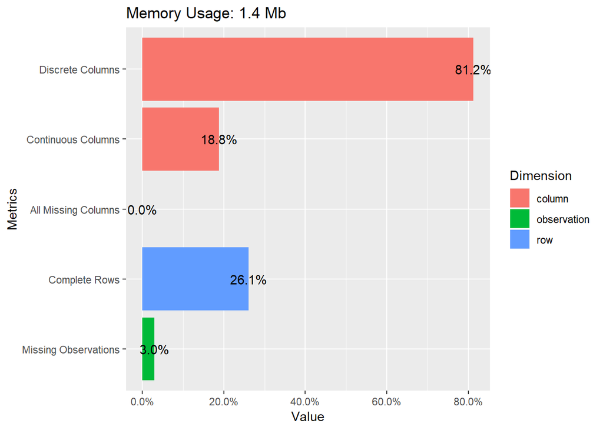

```r
plot_intro(dat)
```

Lets also check our variables for correlation, this will make it easier to confirm if a question is possible to answer or not.

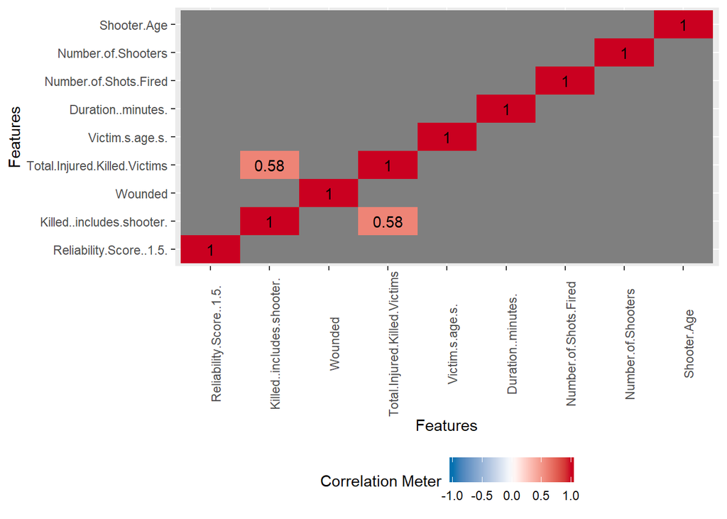

```r
dat %>%
  plot_correlation(type = "c")
```

** discrete values not working

# Question 1

What is the preferred type of weapon/firearm used by the shooters in our ds?

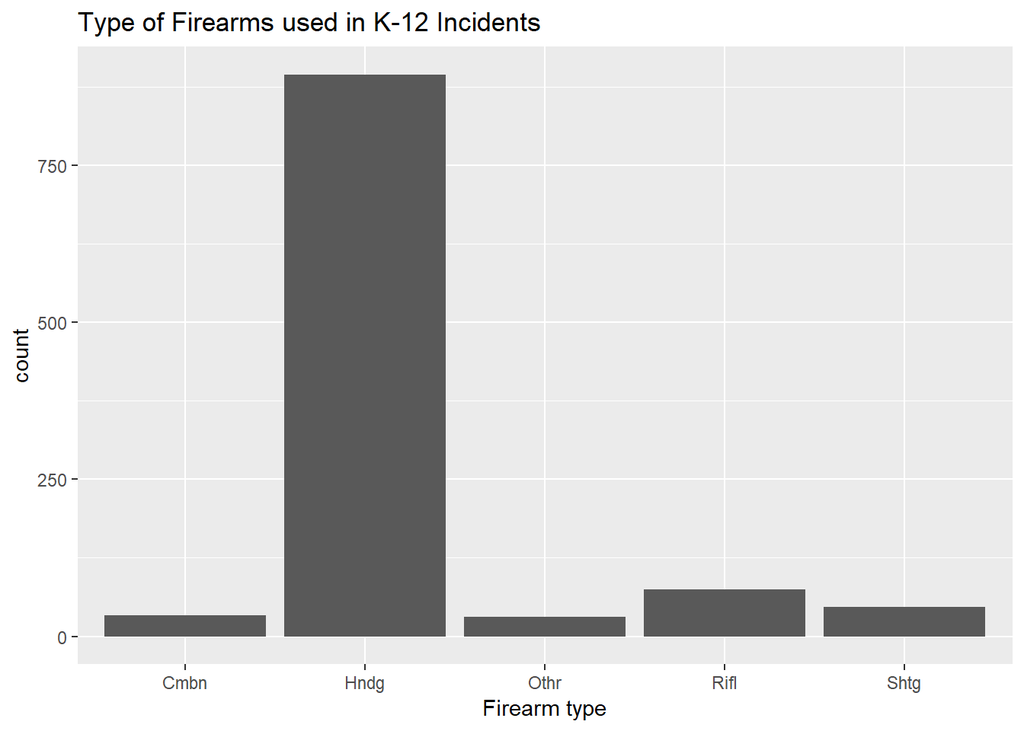

```r
dat %>%
  ggplot(aes(x = Firearm.Type)) +
  geom_histogram(stat = "count") +
  labs(title = "Type of Firearms used in K-12 Incidents", x = "Firearm type", y = "count") + scale_x_discrete(labels = abbreviate, limits = c("Combination", "Handgun", "Other", "Rifle", "Shotgun"))
```

Handguns were used in easily the majority of these shootings.

# Question 2

What kind of shootings have the most victims? Reasoning being somewhat stoic, but when shooters are more “angry”, does this have any affect on the number of lives they take?

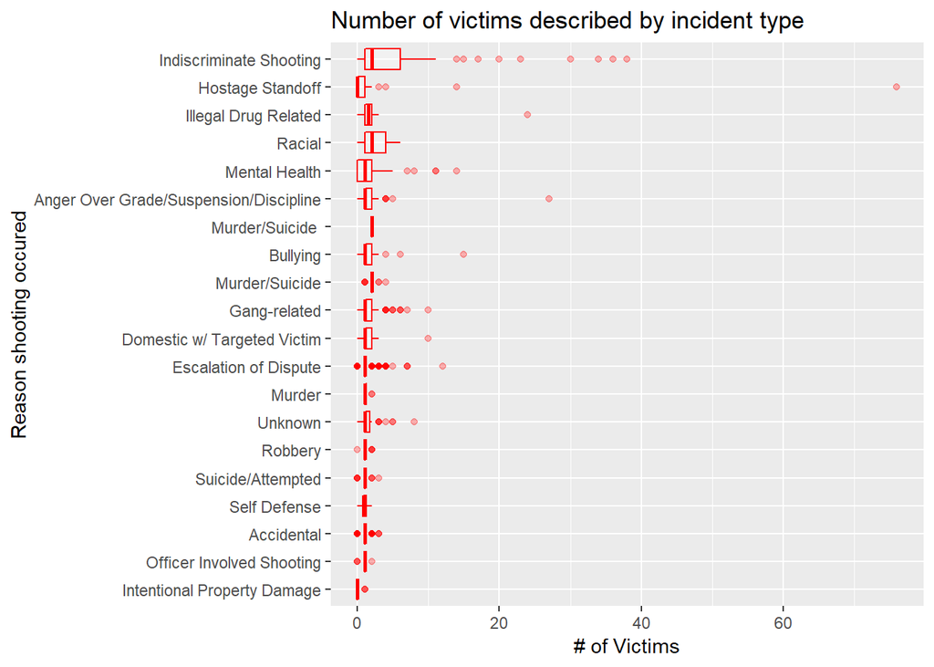

```r
dat %>%
  ggplot(aes(x = reorder(as.factor(Category), Total.Injured.Killed.Victims), y = Total.Injured.Killed.Victims)) +
  geom_boxplot(alpha = .3, color = "red") +
  coord_flip() +
  labs(title = "Number of victims described by incident type", y = "# of Victims",
         x = "Reason shooting occured")
```

It seems as though this can be somewhat confirmed, however plausible at best. The main observation is that shootings that occured due to Race, Mental Health, Murder/suicide, Hostages, and illegal drug related tend to have more victims.

What is most surprising is that shootings deemed “indiscriminate” tend to have the most victims. Could this be a reporting error, as we don’t have techniques, etc to recognize the cause behind these shootings? Or is it more likely when the “indiscriminate” shooters are searching out targets, everyone becomes a target.

Lucky for us, we can check to see in how may of these cases the shooter was targetting anyone specifically.

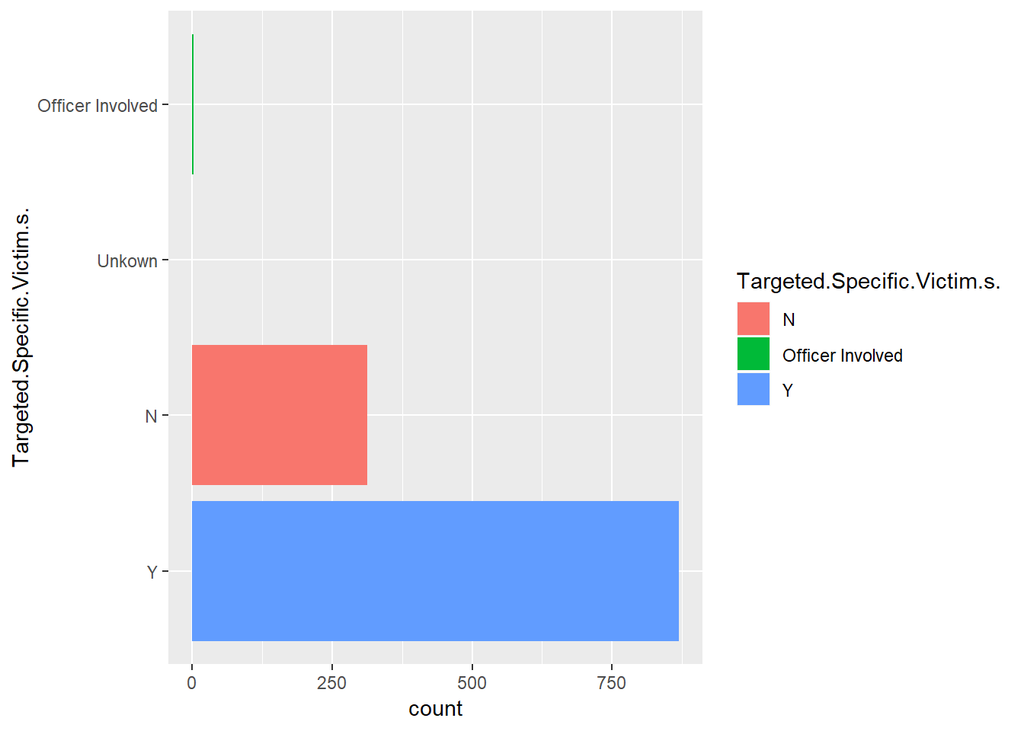

```r
dat %>%
  ggplot(aes(x = Targeted.Specific.Victim.s., fill = Targeted.Specific.Victim.s.)) +
  geom_bar() + coord_flip() + xlim("Y", "N", "Unkown", "Officer Involved")
```

This seems to contradict our thoughts above, concerning who is the target when the shooting is “indiscriminate”. This points to make our “anger hypothesis” more plausible than the former.

# Question 3